# Assignment 2 -fml

Chirag gupta

2025-09-26

```r
## Loading necessary libraries
library(caret) #For Knn Classification
library(class) #For data preprocessing
library(readr) #to read csv file
```

```r
# QUESTION 1- Importing and Preparing universal bank data set
bank <- read_csv("C:/Users/devil/Downloads/UniversalBank.csv")
summary(bank)
```

```
##        ID            Age          Experience       Income          ZIP Code
##  Min.   :   1   Min.   :23.00   Min.   :-3.0   Min.   :  8.00   Min.   : 9307
##  1st Qu.:1251   1st Qu.:35.00   1st Qu.:10.0   1st Qu.: 39.00   1st Qu.:91911
##  Median :2500   Median :45.00   Median :20.0   Median : 64.00   Median :93437
##  Mean   :2500   Mean   :45.34   Mean   :20.1   Mean   : 73.77   Mean   :93153
##  3rd Qu.:3750   3rd Qu.:55.00   3rd Qu.:30.0   3rd Qu.: 98.00   3rd Qu.:94608
##  Max.   :5000   Max.   :67.00   Max.   :43.0   Max.   :224.00   Max.   :96651
##      Family          CCAvg          Education        Mortgage
##  Min.   :1.000   Min.   : 0.000   Min.   :1.000   Min.   :  0.0
##  1st Qu.:1.000   1st Qu.: 0.700   1st Qu.:1.000   1st Qu.:  0.0
##  Median :2.000   Median : 1.500   Median :2.000   Median :  0.0
##  Mean   :2.396   Mean   : 1.938   Mean   :1.881   Mean   : 56.5
##  3rd Qu.:3.000   3rd Qu.: 2.500   3rd Qu.:3.000   3rd Qu.:101.0
##  Max.   :4.000   Max.   :10.000   Max.   :3.000   Max.   :635.0
##  Personal Loan   Securities Account   CD Account         Online
##  Min.   :0.000   Min.   :0.0000     Min.   :0.0000   Min.   :0.0000
##  1st Qu.:0.000   1st Qu.:0.0000     1st Qu.:0.0000   1st Qu.:0.0000
##  Median :0.000   Median :0.0000     Median :0.0000   Median :1.0000
##  Mean   :0.096   Mean   :0.1044     Mean   :0.0604   Mean   :0.5968
##  3rd Qu.:0.000   3rd Qu.:0.0000     3rd Qu.:0.0000   3rd Qu.:1.0000
##  Max.   :1.000   Max.   :1.0000     Max.   :1.0000   Max.   :1.0000
##    CreditCard
##  Min.   :0.000
##  1st Qu.:0.000
##  Median :0.000
##  Mean   :0.294
##  3rd Qu.:1.000
##  Max.   :1.000
```

```r
str(bank)
```

```
## spc_tbl_ [5,000 × 14] (S3: spec_tbl_df/tbl_df/tbl/data.frame)
##  $ ID                : num [1:5000] 1 2 3 4 5 6 7 8 9 10 ...
##  $ Age               : num [1:5000] 25 45 39 35 35 37 53 50 35 34 ...
##  $ Experience        : num [1:5000] 1 19 15 9 8 13 27 24 10 9 ...
##  $ Income            : num [1:5000] 49 34 11 100 45 29 72 22 81 180 ...
##  $ ZIP Code          : num [1:5000] 91107 90089 94720 94112 91330 ...
##  $ Family            : num [1:5000] 4 3 1 1 4 4 2 1 3 1 ...
##  $ CCAvg             : num [1:5000] 1.6 1.5 1 2.7 1 0.4 1.5 0.3 0.6 8.9 ...
##  $ Education         : num [1:5000] 1 1 1 2 2 2 2 3 2 3 ...
##  $ Mortgage          : num [1:5000] 0 0 0 0 0 155 0 0 104 0 ...
##  $ Personal Loan     : num [1:5000] 0 0 0 0 0 0 0 0 0 1 ...
##  $ Securities Account: num [1:5000] 1 1 0 0 0 0 0 0 0 0 ...
##  $ CD Account        : num [1:5000] 0 0 0 0 0 0 0 0 0 0 ...
##  $ Online            : num [1:5000] 0 0 0 0 0 1 1 0 1 0 ...
##  $ CreditCard        : num [1:5000] 0 0 0 0 1 0 0 1 0 0 ...
##  - attr(*, "spec")=
##   .. cols(
##   ..   ID = col_double(),
##   ..   Age = col_double(),
##   ..   Experience = col_double(),
##   ..   Income = col_double(),
##   ..   `ZIP Code` = col_double(),
##   ..   Family = col_double(),
##   ..   CCAvg = col_double(),
##   ..   Education = col_double(),
##   ..   Mortgage = col_double(),
##   ..   `Personal Loan` = col_double(),
##   ..   `Securities Account` = col_double(),
##   ..   `CD Account` = col_double(),
##   ..   Online = col_double(),
##   ..   CreditCard = col_double()
##   .. )
##  - attr(*, "problems")=<externalptr>
```

```r
#removing unwanted variable id, zipcode
new_bank<-bank[, -c(1,5)]
new_bank
```

```
## # A tibble: 5,000 × 12
##      Age Experience Income Family CCAvg Education Mortgage `Personal Loan`
##    <dbl>      <dbl>  <dbl>  <dbl> <dbl>     <dbl>    <dbl>           <dbl>
##  1    25          1     49      4   1.6         1        0               0
##  2    45         19     34      3   1.5         1        0               0
##  3    39         15     11      1   1           1        0               0
##  4    35          9    100      1   2.7         2        0               0
##  5    35          8     45      4   1           2        0               0
##  6    37         13     29      4   0.4         2      155               0
##  7    53         27     72      2   1.5         2        0               0
##  8    50         24     22      1   0.3         3        0               0
##  9    35         10     81      3   0.6         2      104               0
## 10    34          9    180      1   8.9         3        0               1
## # ℹ 4,990 more rows
## # ℹ 4 more variables: `Securities Account` <dbl>, `CD Account` <dbl>,
## #   Online <dbl>, CreditCard <dbl>
```

```r
#COnverting variable(EDUCATION)
new_bank$Education <- as.factor(new_bank$Education)
str(new_bank)
```

```
## tibble [5,000 × 12] (S3: tbl_df/tbl/data.frame)
##  $ Age               : num [1:5000] 25 45 39 35 35 37 53 50 35 34 ...
##  $ Experience        : num [1:5000] 1 19 15 9 8 13 27 24 10 9 ...
##  $ Income            : num [1:5000] 49 34 11 100 45 29 72 22 81 180 ...
##  $ Family            : num [1:5000] 4 3 1 1 4 4 2 1 3 1 ...
##  $ CCAvg             : num [1:5000] 1.6 1.5 1 2.7 1 0.4 1.5 0.3 0.6 8.9 ...
##  $ Education         : Factor w/ 3 levels "1","2","3": 1 1 1 2 2 2 2 3 2 3 ...
##  $ Mortgage          : num [1:5000] 0 0 0 0 0 155 0 0 104 0 ...
##  $ Personal Loan     : num [1:5000] 0 0 0 0 0 0 0 0 0 1 ...
##  $ Securities Account: num [1:5000] 1 1 0 0 0 0 0 0 0 0 ...
##  $ CD Account        : num [1:5000] 0 0 0 0 0 0 0 0 0 0 ...
##  $ Online            : num [1:5000] 0 0 0 0 0 1 1 0 1 0 ...
##  $ CreditCard        : num [1:5000] 0 0 0 0 1 0 0 1 0 0 ...
```

```r
names(new_bank$Education)
```

[output not shown]

```r
#Conevrting categorical variable into dummy variable and getting a new data set
dummy_education <- dummyVars(~., data =new_bank)
new_bank <- as.data.frame(predict(dummy_education, new_bank))
head(new_bank)
```

```
##   Age Experience Income Family CCAvg Education.1 Education.2 Education.3
## 1  25          1     49      4   1.6           1           0           0
## 2  45         19     34      3   1.5           1           0           0
## 3  39         15     11      1   1.0           1           0           0
## 4  35          9    100      1   2.7           0           1           0
## 5  35          8     45      4   1.0           0           1           0
## 6  37         13     29      4   0.4           0           1           0
##   Mortgage `Personal Loan` `Securities Account` `CD Account` Online CreditCard
## 1        0               0                    1            0      0          0
## 2        0               0                    1            0      0          0
## 3        0               0                    0            0      0          0
## 4        0               0                    0            0      0          0
## 5        0               0                    0            0      0          1
## 6      155               0                    0            0      1          0
```

```r
#removing the backtick from personal loan
names(new_bank) <- make.names(names(new_bank))
#removing x from them
clean_names <- function(names_vec) {
  names_vec <- gsub("^X\\.", "", names_vec)   # Remove leading 'X.'
  names_vec <- gsub("\\.$", "", names_vec)    # Remove trailing '.'
  return(names_vec)
}
names(new_bank) <- clean_names(names(new_bank))
colnames(new_bank)
```

```
##  [1] "Age"                "Experience"         "Income"
##  [4] "Family"             "CCAvg"              "Education.1"
##  [7] "Education.2"        "Education.3"        "Mortgage"
## [10] "Personal.Loan"      "Securities.Account" "CD.Account"
## [13] "Online"             "CreditCard"
```

```r
##Answer 1: Splitting Dataset into Training, Validation Sets
set.seed(123)
train_Index <- createDataPartition(new_bank$Personal.Loan, p=0.6, list=FALSE)
Train <- new_bank[train_Index,]
validation <- new_bank[-train_Index,]
#excluding target variable personal loan from it
train_predictor <-Train[,-10]
validation_predicator <- validation[,-10]
colnames(train_predictor)
```

```
##  [1] "Age"                "Experience"         "Income"
##  [4] "Family"             "CCAvg"              "Education.1"
##  [7] "Education.2"        "Education.3"        "Mortgage"
## [10] "Securities.Account" "CD.Account"         "Online"
## [13] "CreditCard"
```

```r
#Normalizing the train and validation
new_bank_normalized <-preProcess(Train[,-10], method=c("center", "scale"))
train_label <-predict(new_bank_normalized,Train[,-10])
validation_label <-predict(new_bank_normalized,validation[,-10])
```

Interpretation The universal bank dataset, is divided into two sections in the section above:60% for training, 40% for validation, and later removed the target variable(personal laon) and then normalized the data.

```r
#ANSWER 2- k-NN Classification
#Adding a new customer
new_customer_record <- data.frame(
  Age = 40,
  Experience = 10,
  Income = 84,
  Family = 2,
  CCAvg = 2,
  Education.1 = 0,
  Education.2 = 1,
  Education.3 = 0,
  Mortgage = 0,
  Securities.Account = 0,
  CD.Account = 0,
  Online = 1,
  CreditCard = 1
)
#Normalizing new data
names(new_bank_normalized)
```

```
##  [1] "dim"               "bc"                "yj"
##  [4] "et"                "invHyperbolicSine" "mean"
##  [7] "std"               "ranges"            "rotation"
## [10] "method"            "thresh"            "pcaComp"
## [13] "numComp"           "ica"               "wildcards"
## [16] "k"                 "knnSummary"        "bagImp"
## [19] "median"            "data"              "rangeBounds"
```

```r
new_customer <-new_customer_record
new_customer <-predict(new_bank_normalized, new_customer_record)
```

Interpretation In the above section, a data frame for the new sample dataset is created using the specified variable values, and the data frame is normalized using the same normalization parameters as the bank dataset.

```r
#Determining the Optimal k Value
# Running k-NN classification with k = 1 for the new customer record
knn.prediction1 <- class::knn(train = train_label,
                       test = new_customer,
                       cl = Train$Personal.Loan, k = 1)
knn.prediction1
```

```
## [1] 0
## Levels: 0 1
```

Interpretation The k-NN model classified the new customer entry as 0,meaning that the new customer will not accept the loan

```r
# ANSWER-3 Finding the value of k that balance between underfitting and over fitting
accuracy_data <- data.frame(k = seq(1, 15, 1), overallaccuracy = rep(0, 15))
for (i in 1:15) {
  knn.pred<-class::knn(train=train_label,
                       test=validation_label,
                       cl=Train$Personal.Loan, k=i)

  accuracy_data[i,2]<-confusionMatrix(knn.pred,as.factor(validation$Personal.Loan),positive ="1")$overall[1]

}
which(accuracy_data[,2]==max(accuracy_data[,2]))
```

```
## [1] 1
```

Interpretation : The k-NN model was evaluated for k. loop for K values between 1 and 15 are used to determine the appropriate balance of overfitting to underfitting. which returned k=1 which means the maximum overall accuracy attained at k=1.

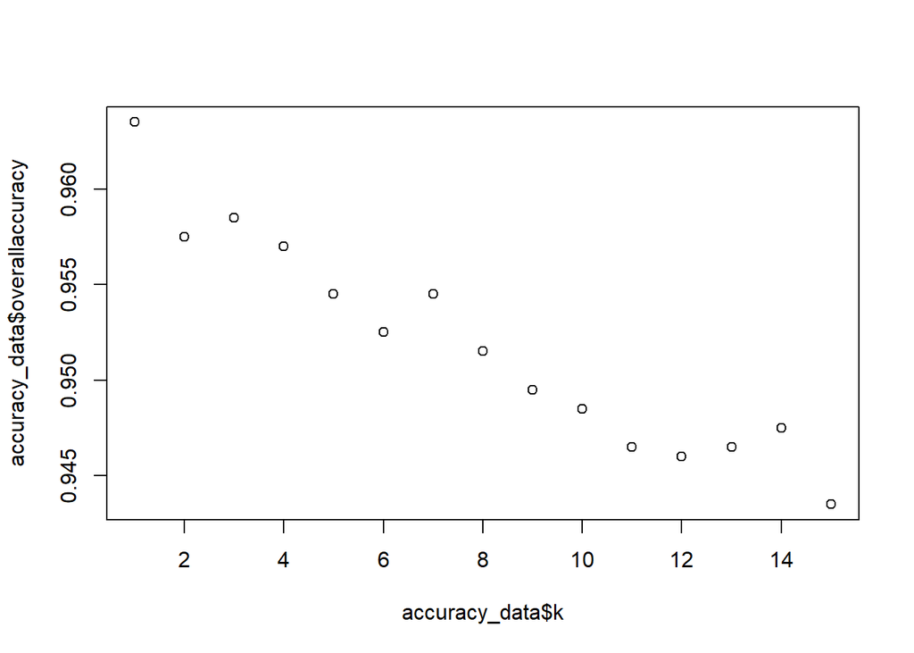

```r
# Plotting accuracy results against k values
plot(accuracy_data$k,accuracy_data$overallaccuracy)
```

```r
# STEP 4: Confusion matrix for validation set using best k
best_k <- 1   # from above loop
knn.pred.best <- class::knn(train = train_label,
                            test = validation_label,
                            cl = Train$Personal.Loan,
                            k = best_k)

conf_matrix <- confusionMatrix(knn.pred.best,
                               as.factor(validation$Personal.Loan),
                               positive = "1")
conf_matrix
```

```
## Confusion Matrix and Statistics
##
##           Reference
## Prediction    0    1
##          0 1776   51
##          1   22  151
##
##                Accuracy : 0.9635
##                  95% CI : (0.9543, 0.9713)
##     No Information Rate : 0.899
##     P-Value [Acc > NIR] : < 2.2e-16
##
##                   Kappa : 0.7853
##
##  Mcnemar's Test P-Value : 0.001049
##
##             Sensitivity : 0.7475
##             Specificity : 0.9878
##          Pos Pred Value : 0.8728
##          Neg Pred Value : 0.9721
##              Prevalence : 0.1010
##          Detection Rate : 0.0755
##    Detection Prevalence : 0.0865
##       Balanced Accuracy : 0.8676
##
##        'Positive' Class : 1
##
```

INTERPERTATION This gives accuracy, sensitivity, specificity, and the full confusion matrix for the validation data at best k.

Sensitivity = ability to correctly predict loan acceptance (class 1).

Specificity = ability to correctly predict non-acceptance (class 0)

```r
# STEP 5: Classifying the new customer with best k
new_customer_pred <- class::knn(train = train_label,
                                test = new_customer,
                                cl = Train$Personal.Loan,
                                k = best_k)
new_customer_pred
```

```
## [1] 0
## Levels: 0 1
```

Interpretation: The output is 0 which means that the new customer has not accepted the loan.

```r
#ANSWER- REPARTATION OF DATASET
# STEP 6: Repartition into Train:Validation:Test (50:30:20)
set.seed(123)
train_index2 <- createDataPartition(new_bank$Personal.Loan, p = 0.5, list = FALSE)
Train2 <- new_bank[train_index2, ]
temp <- new_bank[-train_index2, ]

# split temp into validation (30%) and test (20%)
val_index <- createDataPartition(temp$Personal.Loan, p = 0.6, list = FALSE)
Validation2 <- temp[val_index, ]
Test2 <- temp[-val_index, ]

# prepare predictors (exclude target var)
train_pred2 <- Train2[, -10]
val_pred2   <- Validation2[, -10]
test_pred2  <- Test2[, -10]

# normalize with training
norm2 <- preProcess(train_pred2, method = c("center", "scale"))
train_norm2 <- predict(norm2, train_pred2)
val_norm2   <- predict(norm2, val_pred2)
test_norm2  <- predict(norm2, test_pred2)
```

```r
#NOW RUNNING WITH BEST VALUE OF K
# Training prediction
train_knn <- class::knn(train = train_norm2,
                        test = train_norm2,
                        cl = Train2$Personal.Loan,
                        k = best_k)

train_conf <- confusionMatrix(train_knn, as.factor(Train2$Personal.Loan), positive = "1")
train_conf
```

```
## Confusion Matrix and Statistics
##
##           Reference
## Prediction    0    1
##          0 2271    0
##          1    0  229
##
##                Accuracy : 1
##                  95% CI : (0.9985, 1)
##     No Information Rate : 0.9084
##     P-Value [Acc > NIR] : < 2.2e-16
##
##                   Kappa : 1
##
##  Mcnemar's Test P-Value : NA
##
##             Sensitivity : 1.0000
##             Specificity : 1.0000
##          Pos Pred Value : 1.0000
##          Neg Pred Value : 1.0000
##              Prevalence : 0.0916
##          Detection Rate : 0.0916
##    Detection Prevalence : 0.0916
##       Balanced Accuracy : 1.0000
##
##        'Positive' Class : 1
##
```

```r
# Validation prediction
val_knn <- class::knn(train = train_norm2,
                      test = val_norm2,
                      cl = Train2$Personal.Loan,
                      k = best_k)

val_conf <- confusionMatrix(val_knn, as.factor(Validation2$Personal.Loan), positive = "1")
val_conf
```

```
## Confusion Matrix and Statistics
##
##           Reference
## Prediction    0    1
##          0 1335   42
##          1   22  101
##
##                Accuracy : 0.9573
##                  95% CI : (0.9458, 0.967)
##     No Information Rate : 0.9047
##     P-Value [Acc > NIR] : 9.966e-15
##
##                   Kappa : 0.7361
##
##  Mcnemar's Test P-Value : 0.01755
##
##             Sensitivity : 0.70629
##             Specificity : 0.98379
##          Pos Pred Value : 0.82114
##          Neg Pred Value : 0.96950
##              Prevalence : 0.09533
##          Detection Rate : 0.06733
##    Detection Prevalence : 0.08200
##       Balanced Accuracy : 0.84504
##
##        'Positive' Class : 1
##
```

```r
# Test prediction
test_knn <- class::knn(train = train_norm2,
                       test = test_norm2,
                       cl = Train2$Personal.Loan,
                       k = best_k)

test_conf <- confusionMatrix(test_knn, as.factor(Test2$Personal.Loan), positive = "1")
test_conf
```

```
## Confusion Matrix and Statistics
##
##           Reference
## Prediction   0   1
##          0 885  29
##          1   7  79
##
##                Accuracy : 0.964
##                  95% CI : (0.9505, 0.9747)
##     No Information Rate : 0.892
##     P-Value [Acc > NIR] : < 2.2e-16
##
##                   Kappa : 0.7948
##
##  Mcnemar's Test P-Value : 0.0004653
##
##             Sensitivity : 0.7315
##             Specificity : 0.9922
##          Pos Pred Value : 0.9186
##          Neg Pred Value : 0.9683
##              Prevalence : 0.1080
##          Detection Rate : 0.0790
##    Detection Prevalence : 0.0860
##       Balanced Accuracy : 0.8618
##
##        'Positive' Class : 1
##
```

INTERPERATION training Set: TN (True Negatives) = 2271 FP (False Positives) = 0 FN (False Negatives) = 0 TP (True Positives) = 229 Accuracy = (TP + TN) / (TP+TN+FP+FN) = (229 + 2271) / (229 + 2271 + 0 + 0) = 1.000 (100%)

Sensitivity = TP / (TP+FN) = 229 / (229+0) = 1.0000 (100%) Specificity = TN / (TN+FP) = 2271 / (2271+0) = 1.0000 (100%)

The training model is perfectly fitting the training set. This is expected with k=1, but it may indicate overfitting since real-world data won’t be classified this perfectly.

validation set: TN = 1335 FP = 22 FN = 42 TP = 101 Accuracy = (101+1335) / (101+1335+22+42) = 1436 / 1500 = 0.9573 (95.73%) accuracy drops slightly to 95.7%.

Sensitivity = 101 / (101+42) = 0.706 (70.63%) Specificity = 1335 / (1335+22) = 0.9838 (98.38%)

The model is very strong at identifying non-loan customers (specificity ~98%).

However, it struggles more to detect loan acceptances (sensitivity ~71%), meaning it misses about 3 out of 10 actual positives.

test set: TN = 885 FP = 7 FN = 29 TP = 79 Accuracy = (79+885) / (79+885+7+29) = 964 / 1000 = 0.964 (96.4%)

Sensitivity = 79 / (79+29) = 0.7315 (73.15%) Specificity = 885 / (885+7) = 0.9922 (99.22%)

The model achieves 96.4% accuracy.

Again, specificity is very high (99.2%), so the model is excellent at ruling out non-loan customers.

Sensitivity is 73.1%, which means it correctly identifies about 3 out of 4 loan customers but still misses some.

[output not shown]